# Quantifying School Desegregation

Draft Version - DO NOT SHARE OR CITE

Nathan Alexander, PhD [^1]

# 1 Abstract

**Keywords**

*Brown v. Board of Education*, desegregation, segregation, race, mathematical modeling

**Citation**

Alexander, N. N. (2024). Quantifying School Desegregation.

# 2 Introduction

## 2.1 Motivation for the study

As the 70th year anniversary of the *Brown v. Board* Supreme Court decision prompts researchers to take a critical examination and the history and progress of racial discrimination in U.S. schools, this article seeks to offer an abstract discourse to support extensive and dynamic studies of segregation.

# 3 Conceptualizing Desegregation

To first conceptualize the policies, we take a small subset of articles to contextualize the article under analysis. Given the function of JNE historically, this subset of articles offers readers a glimpse into the themes and different focal points of related work for the 20-year period prior to the publication of Giles’ work. I use Google Scholar to identify initial articles with the syntax ‘source=The AND source=Journal AND source=Of AND source=Negro AND source=Education’.

I first examined research articles published in JNE between the period of 1954 and 1974 whose content included the term “Brown v Board” in either the title or body text; abstracts were not included in a majority of PDF version of the articles. This initial search returned 29 articles.

Giles’ work is one of these articles.

# 4 Modeling Segregation

While Giles (1974) takes a structural apprach, we find other popular studies of segregation focused on *Brown* have taken on an individual student approach, measuring effects of segregation at the individual level. One core paper that takes on both approaches is the work by Reardon & Owens (2014) in *60 Years after Brown: Trends and Consequences of School Segregation*.

## 4.1 Structural interpretations: Neighborhoods in the United States

Reardon & Owens (2014), citing the work of Massey & Denton (1988), note that ``school segregation is typically measured using one of two types of segregation indices: measures of isolation or exposutre and measures of uneveness” (p. 201).

## 4.2 Mixed interpretations: Schools in U.S. neighborhoods

## 4.3 Individual interpretations: Students in U.S. schools

### 4.3.1 Definitions

Based on the aforementioned theoretical frameworks, we provide a few important definitions to advance our understanding of and critiques around the proposed model. These definitions provide for a shift between the formal (i.e., mathematical) and more intuitive (i.e., sociological) formations discussed in forthcoming sections.

Definitions of segregation index terms with examples[^2]

| Term | Definition | Example |
| --- | --- | --- |
| $n$ | The number of areas, ranked by land (smallest to largest) | 8 Chicagoland neighborhoods |
| $m$ | The number of areas, ranked by distance (increasing) | 10 miles from downtown |

# 5 Mathematical models

The index of dissimilarity is a widely used measure of segregation that examines the demographic makeup of a given geographic area, $G$, based on the distribution of two groups across a set of $N$ neighborhoods which constitute area $G$. Despite its limitations when considering non-binary measures of racial segregation, the index of dissimilarity provides the unique ability to explore more focused conceptions of racism|known as anti-Blackness|that play out at the neighborhood level.

Modern data science applications and tools have produced new lines of scholarly inquiry that are increasingly critical. This critical stance is often a combination or result of advances in mathematical modeling capabilities and shifts in the research priorities at sub-disciplinary levels. Importantly, these inquiries are also a result of a decades long focus among educators, and especially those educations in science, technology, engineering, and mathematics (STEM), looking to integrate group-worthy, culturally-relevant, and justice-oriented practices.

Moreover, increases in the collection and availability of data at more local levels, which have presented opportunities for more acute analyses. These burgeoning fields of study, such as mathematical sociology and mathematical psychology, can take into consideration both the formal and more intuitive formations of the social world. In mathematical psychology, for example, these interdisciplinary connections have expanded back into the more dominant fields as new tools are acquired that allow researchers to ask and answer previously unanswerable questions. One example at the intersection of data science and interdisciplinary study is the rapid expansion of research on neural networks.

As these new findings and tools emerge, researchers have been able to connect data sources to more nuanced and critical frameworks. This integration|of more localized data and new conceptual and theoretical frameworks|has increased the possibility of interdisciplinary analyses that consider the logical and computational matters alongside real-world applications and examples in real-time. The field of mathematical sociology is another example of a rapidly increasing interdisciplinary domain of study, and in the context of data science may be best known for its contributions to inquiries related to social networks.

## 5.1 Model 1: Index of Dissimilarity

The index of dissimilarity, $D$, is a measure that scores the evenness of two groups across a set of indexed neighborhoods, $n_i$, within some larger component geographic area, $G$. $D$ can also be interpreted as the calculated proportion of one of two groups that would need to move to different neighborhoods in order to produce a distribution that matches that of the larger geographic area. In both of these instances, $D$ can be used to measure segregation as a function of neighborhood composition where a score of $0$ indicates a fully integrated geographical area and a score of $1$ represents complete segregation. The basic formula for the index of dissimilarity is:

$$\begin{equation}\label{eq:1}
D = \frac{1}{2} \sum_{i=1}^{N} \Bigl|\frac{a_i}{A} -
\frac{b_i}{B}\Bigr|
\end{equation}$$

with $a_i$, $b_i$ $\in$ $\mathbb{Z}^{0+}$ where $a_i$ is the population of group A in the $i^{th}$ neighborhood; A is the total population of group A in the broader geographical area $G$; $b_i$ is the population of group B in the $i^{th}$ neighborhood; and B is the total population of group B in the broader geographical area $G$. The model assumes the existence of at least two groups in $G$ such that $A \neq 0$ and $B \neq 0$.

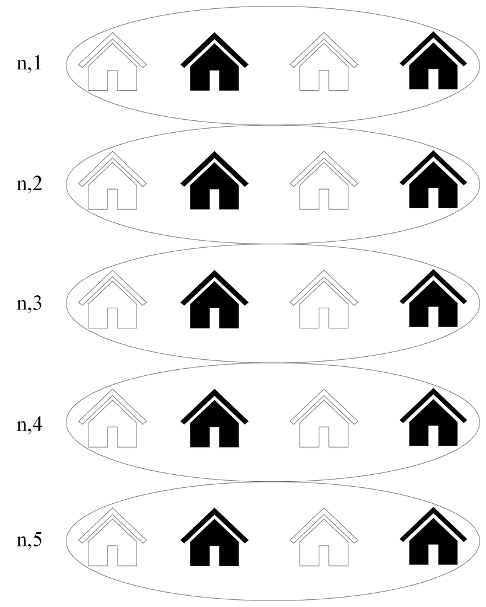

Horizontal neighborhood schema

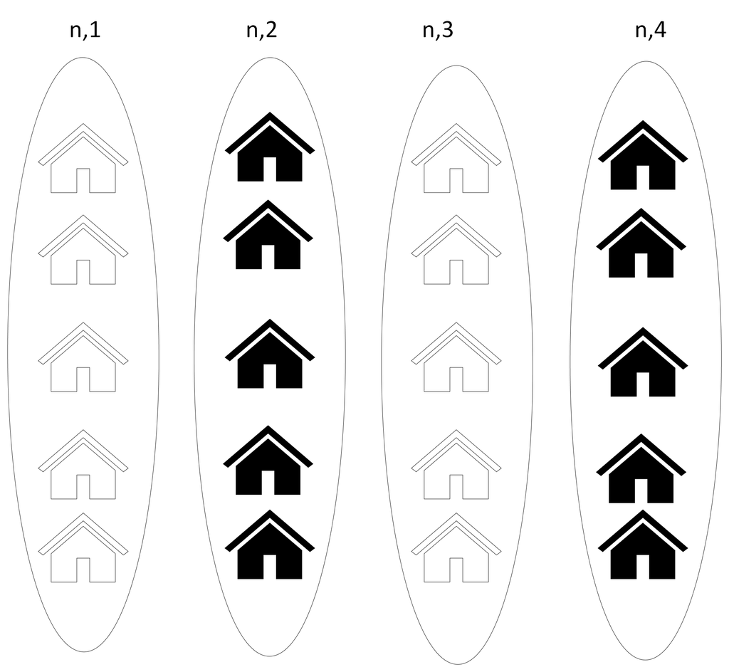

Vertical neighborhood schema

#### 5.1.0.1 Linear algebra perspective

Importantly, there are key connections to linear algebra for the index of dissimilarity that prove useful for computation, data wrangling, and data analysis. When viewed from a linear algebra perspective, we provide direct connections to the structure of data sets that house information on a set of indexed neighborhoods. These data can be used to examine dynamic models of the same geographical area $G$.

First, we assume that the set $G$ indexes a set of non-overlapping, or partitioned, neighborhoods to be analyzed such that

$$\begin{equation}\label{eq:2}
G = \{n_i | i \in \mathbb{N}\}
\end{equation}$$

or, more intuitively, $G$ = {neighborhood 1, neighborhood 2, …, neighborhood N}. The partition of the set $G$ is the set of non-empty subsets of neighborhoods in G such that every neighborhood, $n_i$, in G is in exactly one of these subsets. Namely, we say that G is a disjoint union of the subsets. The elements of the subsets are members of the two groups, $A$ and $B$.

$$\begin{equation}\label{eq:3}
\textbf{a} = [ a_1, a_2, ..., a_N]
\end{equation}$$
$$\begin{equation}\label{eq:4}
\textbf{b} = [ b_1, b_2, ..., b_N]
\end{equation}$$

### 5.1.1 Between-group segregation

### 5.1.2 Within-group segregation

## 5.2 Model 2: Index of Isolation

# 6 Notes

# 7 References

Anderson, S. E. (1970). Mathematics and the struggle for Black liberation. *The Black Scholar, 2*(1), 20-27.

Bader, M. D. (2024). Shared Satisfaction among Residents Living in Multiracial Neighborhoods. Social Problems, 71(2), 412-436.

Bathia, S., Fuller, B., Galindo, C., Lagos, F., & Rabe-Hesketh, S. (2023). Finding Integrated Schools? Latino Families Settle in Diverse Suburbs, 2000–2015. RSF: The Russell Sage Foundation Journal of the Social Sciences, 9(2), 104-131.

Bradley L, Bradley G. 1977. The academic achievement of black students in desegregated schools. Rev. Educ. Res. 47:399–449

*Brown v. Board of Education*, 347 U.S. 483 (1954)

Chodrow, P. S. (2017). Structure and information in spatial segregation. Proceedings of the National Academy of Sciences, 114(44), 11591-11596.

Clotfelter CT. 2001. Are whites still fleeing? Racial patterns and enrollment shifts in urban public schools, 1987–1996. J. Policy Anal. Manag. 20(2):199–221

Coleman JS, Kelly SD, Moore JA. 1975. Trends in School Segregation, 1968–73. Washington, DC: Urban Inst.

Cook TD, Armor D, Crain R, Miller N, Stephan W, et al. 1984. School desegregation and black achievement. Rep. Natl. Inst. Educ., Washington, DC

Duncan OD, Duncan B. 1955. A methodological analysis of segregation indexes. Am. Sociol. Rev. 20:210–17

Ellis, M., Wright, R., Fiorio, L., & Holloway, S. (2018). Predicting neighborhood racial change in large US metropolitan areas, 1990–2010. Environment and Planning B: Urban Analytics and City Science, 45(6), 1022-1037.

Ellis, M., Wright, R., Holloway, S., & Fiorio, L. (2018). Remaking white residential segregation: metropolitan diversity and neighborhood change in the United States. *Urban geography, 39*(4), 519-545.

Fiel JE. 2013. Decomposing school resegregation: social closure, racial imbalance, and racial isolation. Am. Sociol. Rev. 78(5):828–48

Fitzgerald, M. R., & Lyons, W. (1978). Measuring urban school desegregation: a cautionary note. *Political Methodology*, 511-530.

Ghazaie, M., Rafieian, M., & Dadashpoor, H. (2022). Making the invisible segregation of diverse neighbourhoods visible. Journal of Housing and the Built Environment, 37(1), 459-482.

Giles, M. W. (1974). Measuring School Desegregation. *The Journal of Negro Education, 43*(4), 517–523. https://doi.org/10.2307/2966711

Giles, M. W. (1975). Black concentration and school district size as predictors of school segregation: the impact of federal enforcement. Sociology of Education, 411-419.

Grier, S. A., & Perry, V. G. (2018). Dog parks and coffee shops: Faux diversity and consumption in gentrifying neighborhoods. Journal of Public Policy & Marketing, 37(1), 23-38.

Hanushek E, Kain JF, Rivkin S. 2009. New evidence about Brown v. Board of Education: the complex effects of school racial composition on achievement. J. Lab. Econ. 27(3):349–83

James DR, Taeuber K. 1985. Measures of segregation. Sociol. Methodol. 14:1–32

Kahlenberg RD. 2006. Socioeconomic school integration. N.C. Law Rev. 85:1545–94

Klein, M. R. (2018). Beyond Body Mixing: Race, Space, and the Meaning of School Integration in a Chicago Suburb (Doctoral dissertation, Loyola University Chicago).

Lacayo, C. (2016). Latinos need to stay in their place: differential segregation in a multi-ethnic suburb. Societies, 6(3), 25.

Lee B, Reardon SF, Firebaugh G, Farrell C, Matthews SA, O’Sullivan D. 2008. Beyond the census tract: patterns and determinants of racial segregation at multiple geographic scales. Am. Sociol. Rev. 73(5):766–91

Lobo, A. P., Flores, R. J., & Salvo, J. J. (2019). Racial Differentials in the Components of Population Change and Neighborhood Transitions in New York City, 1980–2010: The Distinct Role of Asian Net Inflows in the Age of Net Outflows of Whites, Blacks, and Hispanics. Urban Affairs Review, 55(5), 1456-1486.

Mann, B., & Rogers, A. (2021). Segregation now, segregation tomorrow, segregation forever? Racial and economic isolation and dissimilarity in rural Black Belt schools in Alabama. Rural Sociology, 86(3), 523-558.

Massey, D. S., & Denton, N. A. (1988). The dimensions of residential segregation. Social forces, 67(2), 281-315.

Mayer SE. 2002. How economic segregation affects children’s educational attainment. Soc. Forces 81(1):153–76

Maynor, W., & Katzenmeyer, W. G. (1974). Academic performance and school integration: A multi-ethnic analysis. The Journal of Negro Education, 43(1), 30-38.

Mickelson RA, Bottia M. 2009. Integrated education and mathematics outcomes: a synthesis of social science research. N.C. Law Rev. 88:993–1090

Morgan, D. R., & England, R. E. (1982). Large district school desegregation: A preliminary assessment of techniques. Social Science Quarterly, 63(4), 688.

Oakes J. 1985. Keeping Track: How Schools Structure Inequality. New Haven, CT: Yale Univ. Press

Orfield G. 1995. Public opinion and school desegregation. Teach. Coll. Rec. 96(4):654–7

Owens, A. (2019). School segregation by race/ethnicity and economic status. Education and Society: An Introduction to Key Issues in the Sociology of Education, 237-253.

Pinto-Coelho, J. M., & Zuberi, T. (2015). Segregated diversity. Sociology of Race and Ethnicity, 1(4), 475-489.

Reardon, S. F., & Owens, A. (2014). 60 years after Brown: Trends and consequences of school segregation. *Annual Review of Sociology, 40*(1), 199-218.

Reardon SF, Yun JT. 2003. Integrating neighborhoods, segregating schools: the retreat from school desegregation in the South, 1990–2000. N.C. Law Rev. 81(4):1563–96

Reardon SF, Yun JT, Eitle TM. 2000. The changing structure of school segregation: measurement and evidence of multiracial metropolitan-area school segregation, 1989–1995. Demography 37(3):351–64

Rivkin SG. 1994. Residential segregation and school integration. Sociol. Educ. 67(4):279–92

Short, I. (2011). Dividing Walls: Topology and Topography I. https://plus.maths.org/content/dividing-walls-topology-and-topography-i

Simms, A., & Talbert, E. (2019). Racial residential segregation and school choice. Phylon (1960-), 56(1), 33-57.

Simms, A. (2023). Fiscal Fragility in Black Middle-Class Suburbia and Consequences for K–12 Schools and Other Public Services. RSF: The Russell Sage Foundation Journal of the Social Sciences, 9(2), 204-225.

Stern, S. (2021). “Separate, Therefore Equal”: American Spatial Segregation from Jim Crow to Kiryas Joel. RSF: The Russell Sage Foundation Journal of the Social Sciences, 7(1), 67-90.

Tam, T. (2022). A Spatial Examination of Racial-Ethnic Population Patterns in Metro Atlanta Using Bayesian Conditional Autoregressive Models. Spatial Demography, 10(3), 515-559.

Toldson, I. A. (2018). No BS (Bad Stats): Deconstructing the Black-White Achievement Gap using a DuBoisian Framework (Editor’s Commentary). *The Journal of Negro Education, 87*(3), 191-199.

Toldson, I. A. (2019). *No BS (Bad Stats)*. Brill.

Vigdor JL. 2011. School desegregation and the black-white test score gap. In Whither Opportunity: Rising Inequality, Schools, and Children’s Life Chances, ed. GJ Duncan, RJ Murnane, pp. 443–64. New York: Russell Sage Found.

Walton, E. (2017). Spatial assimilation and its discontents: Asian ethnic neighborhood change in California. Urban Geography, 38(7), 993-1018.

Watson T. 2009. Inequality and the measurement of residential segregation by income in American neighborhoods. Rev. Income Wealth 55(3):820–44

Wells AS, Crain RL. 1994. Perpetuation theory and the long-term effects of school desegregation. Rev. Educ. Res. 64:531–55

Wilson FD. 1985. The impact of school desegregation programs on white public-school enrollment, 1968–1976. Sociol. Educ. 58(3):137–53

Wright, R., Ellis, M., Holloway, S. R., & Catney, G. (2020). The instability of highly racially diverse residential neighborhoods in the United States. Sociology of Race and Ethnicity, 6(3), 365-381.

Zuberi, T. (2000). Deracializing social statistics: Problems in the quantification of race. The Annals of the American Academy of Political and Social Science, 568(1), 172-185.

Zuberi, T. (2001). Thicker than blood: How racial statistics lie. U of Minnesota Press.

[^1]: Howard University, nathan.alexander@howard.edu
[^2]: Terms are based on U.S. census definitions which can be access here: https://www.census.gov/topics/housing/housing-patterns/guidance/appendix-b.html